# DESeq and GO analysis

John Favate

# Data processing section

We did not go over this in todays class but this is what I did in order to get the kallisto results we did use. It’s mostly to be for reference, in case you wanted or needed to do this. It encompasses a series of `bash` for loops that remove the adapters from the original data, and then run kallisto on them. This code reflects my file paths, you would have to change them and other aspects of the code to get it to work for you. Also, to reduce the memory footprint, I only print the first few rows of all the previewed data frames into the HTML file.

### Remove adapters

This for loop removes the adapters from each of the files and also writes the output that cutadapt would normally print to the screen to a file for our record. `&>>../../seqdata/2-adapter_removed/cutadapt_report.txt` redirects both `stdout` and `stderr` to the indicated file.

```bash
for file in ../../seqdata/1-raw/*.gz; do
  # define the file name
  file_name=`echo $file | cut -d '/' -f 5 | cut -d '.' -f 1-2`

  # define the output file location
  output_file=../../seqdata/2-adapter_removed/ar-$file_name

  # echo the filename to the cutadapt report, prior to that files report
  echo ----------$file_name---------- >>../../seqdata/2-adapter_removed/cutadapt_report.txt

  # run cutadapt
  cutadapt -a AGATCGGAAGAGCACACGTCTGAACTCCAGTCA -o $output_file $file &>>../../seqdata/2-adapter_removed/cutadapt_report.txt
done
```

The sample names are in the SRA database, we rename so we know what is what. Hnf4αɣDKO = DK0

```bash
mv ../../seqdata/2-adapter_removed/ar-SRR6979501.fastq ../../seqdata/2-adapter_removed/WT-rep1.fq
mv ../../seqdata/2-adapter_removed/ar-SRR6979502.fastq ../../seqdata/2-adapter_removed/WT-rep2.fq
mv ../../seqdata/2-adapter_removed/ar-SRR6979503.fastq ../../seqdata/2-adapter_removed/WT-rep3.fq
mv ../../seqdata/2-adapter_removed/ar-SRR6979510.fastq ../../seqdata/2-adapter_removed/DKO-rep1.fq
mv ../../seqdata/2-adapter_removed/ar-SRR6979511.fastq ../../seqdata/2-adapter_removed/DKO-rep2.fq
mv ../../seqdata/2-adapter_removed/ar-SRR6979512.fastq ../../seqdata/2-adapter_removed/DKO-rep3.fq
```

### Kallisto alignment and quantification

Kallisto (and other aligners) require an index for alignment. We must first make that. Download the file that is to be the reference, I’m downloading a protein coding trancript fasta from gencode ftp://ftp.ebi.ac.uk/pub/databases/gencode/Gencode_mouse/release_M22/gencode.vM22.pc_transcripts.fa.gz

```bash
wget -P ../../alignment/files_to_make_indices/ ftp://ftp.ebi.ac.uk/pub/databases/gencode/Gencode_mouse/release_M22/gencode.vM22.pc_transcripts.fa.gz
```

Make the kallisto index. I’m naming it mouse_cDNA.kidx, the .kidx is arbitray and doesn’t matter but it stands for kallisto index.

```bash
kallisto index -i ../../alignment/kallisto/indices/mouse_cDNA.kidx ../../alignment/files_to_make_indices/gencode.vM22.pc_transcripts.fa.gz
```

Kallisto needs output directories to write to, we make them here.

```bash
for file in ../../seqdata/2-adapter_removed/*.fq; do
  # derive the filename from the path
  file_name=`echo $file | cut -d '/' -f 5 | cut -d '.' -f 1`

  # make output directories
  mkdir -p ../../alignment/kallisto/output/$file_name
done
```

Because these are single end reads, we would like to estimate the length and standard deviation for the reads. This appears to only work with non-compressed files. You would use `gunzip file.fq.gz` to uncompress a file, where `file.fq.gz` needs to be replaced with your filename and/or path.

```bash
for file in ../../seqdata/2-adapter_removed/*.fq; do
  awk 'BEGIN { t=0.0;sq=0.0; n=0;} ;NR%4==2 {n++;L=length($0);t+=L;sq+=L*L;}END{m=t/n;printf("total %d avg=%f stddev=%f\n",n,m,sqrt(sq/n-m*m));}' $file
done
```

Then perform the alignment and quantification. This also saves a report file for what kallisto would print to the screen.

```bash
for file in ../../seqdata/2-adapter_removed/*.fq; do
  # derive the filename from the path
  file_name=`echo $file | cut -d '/' -f 5 | cut -d '.' -f 1`

  # define the output file location
  output_file=../../alignment/kallisto/output/$file_name

  # echo the filename to the kallisto report, prior to that files report
  echo ----------$file_name---------- >>../../alignment/kallisto/output/kallisto_report.txt

  # define the index location
  index=../../alignment/kallisto/indices/mouse_cDNA.kidx

  # run the quantification
  kallisto quant -i $index -o $output_file --single -s 1 -l 50 -t 8 $file &>>../../alignment/kallisto/output/kallisto_report.txt
done
```

`--single` specifies single end reads with a standard deviation of 1 `-s 1` and length of 50 `-l 50` and uses 8 threads `-t 8`. Like in cutadapt, this creates a report file with `&>>../../alignment/kallisto/output/kallisto_report.txt`.

# Move to R for analysis

### Import the data

Due to some software quirks, you must load the packages in this order.

```r
library(tidyverse)
library(DESeq2)
library(ggpubr)
library(org.Mm.eg.db)
```

```r
.libPaths("/projects/community/gen303/")
library(clusterProfiler)
```

Kallisto outputs a series of TSVs, though they’re all named the same thing. Note the use of `sapply` instead of `lapply`. `sapply` with `simplify = FALSE` reads the data frames into list and makes the names of each item in the list whatever the input to `sapply` is, the file path in this case. `lapply` does not do that.

```r
# find the tsv locations
tsv.locs <- dir("../kallisto_results", recursive = TRUE, full.names = TRUE, pattern = ".tsv")

# read them all into a list, then bind_rows that list to get a single data frame
tsv.df <- sapply(tsv.locs, read_tsv, simplify = FALSE) %>%
  bind_rows(.id = "sample")

head(tsv.df)
```

| sample | target_id | length | eff_length | est_counts | tpm |
| --- | --- | --- | --- | --- | --- |
| ../kallisto_results/DKO-rep1/abundance.tsv | ENSMUST00000070533.4\|ENSMUSG00000051951.5\|OTTMUSG00000026353.2\|OTTMUST00000065166.1\|Xkr4-201\|Xkr4\|3634\|UTR5:1-150\|CDS:151-2094\|UTR3:2095-3634\| | 3634 | 3585 | 2 | 0.0409395 |
| ../kallisto_results/DKO-rep1/abundance.tsv | ENSMUST00000208660.1\|ENSMUSG00000025900.12\|OTTMUSG00000049985.3\|OTTMUST00000145515.1\|Rp1-203\|Rp1\|4170\|UTR5:1-54\|CDS:55-4170\| | 4170 | 4121 | 0 | 0.0000000 |
| ../kallisto_results/DKO-rep1/abundance.tsv | ENSMUST00000194992.6\|ENSMUSG00000025900.12\|OTTMUSG00000049985.3\|-\|Rp1-202\|Rp1\|858\|CDS:1-858\| | 858 | 809 | 0 | 0.0000000 |
| ../kallisto_results/DKO-rep1/abundance.tsv | ENSMUST00000027032.5\|ENSMUSG00000025900.12\|OTTMUSG00000049985.3\|OTTMUST00000127195.2\|Rp1-201\|Rp1\|6869\|UTR5:1-127\|CDS:128-6415\|UTR3:6416-6869\| | 6869 | 6820 | 0 | 0.0000000 |
| ../kallisto_results/DKO-rep1/abundance.tsv | ENSMUST00000027035.9\|ENSMUSG00000025902.13\|OTTMUSG00000050014.7\|OTTMUST00000127245.2\|Sox17-201\|Sox17\|3127\|UTR5:1-1082\|CDS:1083-2342\|UTR3:2343-3127\| | 3127 | 3078 | 0 | 0.0000000 |
| ../kallisto_results/DKO-rep1/abundance.tsv | ENSMUST00000195555.1\|ENSMUSG00000025902.13\|OTTMUSG00000050014.7\|OTTMUST00000127249.1\|Sox17-208\|Sox17\|1977\|UTR5:1-635\|CDS:636-1511\|UTR3:1512-1977\| | 1977 | 1928 | 0 | 0.0000000 |

Critically, the entire file path is now the sample name. We can utilize this to extract the sample names, and other information if it was present.

```r
tsv.df2 <- tsv.df %>%                                     # take the data frame
  separate(sample, into = letters[1:4], sep = "/") %>%    # split sample column into new columns about the /, giving them letters as names
  dplyr::select(-c(letters[c(1:2, 4)])) %>%               # remove the columns we don't need
  dplyr::rename("sample" = "c")                           # rename the c column to sample

head(tsv.df2)
```

| sample | target_id | length | eff_length | est_counts | tpm |
| --- | --- | --- | --- | --- | --- |
| DKO-rep1 | ENSMUST00000070533.4\|ENSMUSG00000051951.5\|OTTMUSG00000026353.2\|OTTMUST00000065166.1\|Xkr4-201\|Xkr4\|3634\|UTR5:1-150\|CDS:151-2094\|UTR3:2095-3634\| | 3634 | 3585 | 2 | 0.0409395 |
| DKO-rep1 | ENSMUST00000208660.1\|ENSMUSG00000025900.12\|OTTMUSG00000049985.3\|OTTMUST00000145515.1\|Rp1-203\|Rp1\|4170\|UTR5:1-54\|CDS:55-4170\| | 4170 | 4121 | 0 | 0.0000000 |
| DKO-rep1 | ENSMUST00000194992.6\|ENSMUSG00000025900.12\|OTTMUSG00000049985.3\|-\|Rp1-202\|Rp1\|858\|CDS:1-858\| | 858 | 809 | 0 | 0.0000000 |
| DKO-rep1 | ENSMUST00000027032.5\|ENSMUSG00000025900.12\|OTTMUSG00000049985.3\|OTTMUST00000127195.2\|Rp1-201\|Rp1\|6869\|UTR5:1-127\|CDS:128-6415\|UTR3:6416-6869\| | 6869 | 6820 | 0 | 0.0000000 |
| DKO-rep1 | ENSMUST00000027035.9\|ENSMUSG00000025902.13\|OTTMUSG00000050014.7\|OTTMUST00000127245.2\|Sox17-201\|Sox17\|3127\|UTR5:1-1082\|CDS:1083-2342\|UTR3:2343-3127\| | 3127 | 3078 | 0 | 0.0000000 |
| DKO-rep1 | ENSMUST00000195555.1\|ENSMUSG00000025902.13\|OTTMUSG00000050014.7\|OTTMUST00000127249.1\|Sox17-208\|Sox17\|1977\|UTR5:1-635\|CDS:636-1511\|UTR3:1512-1977\| | 1977 | 1928 | 0 | 0.0000000 |

Confirm that this worked

```r
unique(tsv.df2$sample)
```

```
## [1] "DKO-rep1" "DKO-rep2" "DKO-rep3" "WT-rep1"  "WT-rep2"  "WT-rep3"
```

Now, we look at the target_id column, it has a lot of information in it. Currently we have splice isoforms, but we want to sum the counts for all of the isoforms to a single gene. We’re interested in the gene name and ID for now, the 2nd and 6th things separated by `|`. A preview of one of the target_id columns:

```r
as.character(tsv.df2[1,2])
```

```
## [1] "ENSMUST00000070533.4|ENSMUSG00000051951.5|OTTMUSG00000026353.2|OTTMUST00000065166.1|Xkr4-201|Xkr4|3634|UTR5:1-150|CDS:151-2094|UTR3:2095-3634|"
```

We separate out the target_id column. Note that the pipe needs to be double escaped `\\|` in order for this to work properly. The pipe would be interpreted as “or”, escaping it (the addition of the `\\`) tells the computer to interpret it as the pipe, not “or”.

```r
tsv.df3 <- tsv.df2 %>%                                       # take the df
  separate(target_id, into = letters[1:10], sep = "\\|") %>% # split target_id into letters about the pipe
  dplyr::select(-c(letters[c(1, 3:5,7:10)])) %>%             # remove the letter columns we don't want
  dplyr::rename("gene_id" = "b", "gene" = "f")               # rename the columns we do want

head(tsv.df3)
```

| sample | gene_id | gene | length | eff_length | est_counts | tpm |
| --- | --- | --- | --- | --- | --- | --- |
| DKO-rep1 | ENSMUSG00000051951.5 | Xkr4 | 3634 | 3585 | 2 | 0.0409395 |
| DKO-rep1 | ENSMUSG00000025900.12 | Rp1 | 4170 | 4121 | 0 | 0.0000000 |
| DKO-rep1 | ENSMUSG00000025900.12 | Rp1 | 858 | 809 | 0 | 0.0000000 |
| DKO-rep1 | ENSMUSG00000025900.12 | Rp1 | 6869 | 6820 | 0 | 0.0000000 |
| DKO-rep1 | ENSMUSG00000025902.13 | Sox17 | 3127 | 3078 | 0 | 0.0000000 |
| DKO-rep1 | ENSMUSG00000025902.13 | Sox17 | 1977 | 1928 | 0 | 0.0000000 |

So we group sample, gene_id, and gene name, summing the counts for each gene. We also round the counts because down the line, DESeq will require integers.

```r
tsv.df4 <- tsv.df3 %>%
  group_by(sample, gene_id, gene) %>%
  summarise(est_counts = round(sum(est_counts)))

head(tsv.df4)
```

| sample | gene_id | gene | est_counts |
| --- | --- | --- | --- |
| DKO-rep1 | ENSMUSG00000000001.4 | Gnai3 | 4896 |
| DKO-rep1 | ENSMUSG00000000003.15 | Pbsn | 0 |
| DKO-rep1 | ENSMUSG00000000028.15 | Cdc45 | 276 |
| DKO-rep1 | ENSMUSG00000000037.17 | Scml2 | 15 |
| DKO-rep1 | ENSMUSG00000000049.11 | Apoh | 13 |
| DKO-rep1 | ENSMUSG00000000056.7 | Narf | 1300 |

### Basic plots

It’s easy to make lots of plots with this data, for example, the distribution of read counts. This was very high coverage data, so many of the genes have around 1000 reads mapping to them.

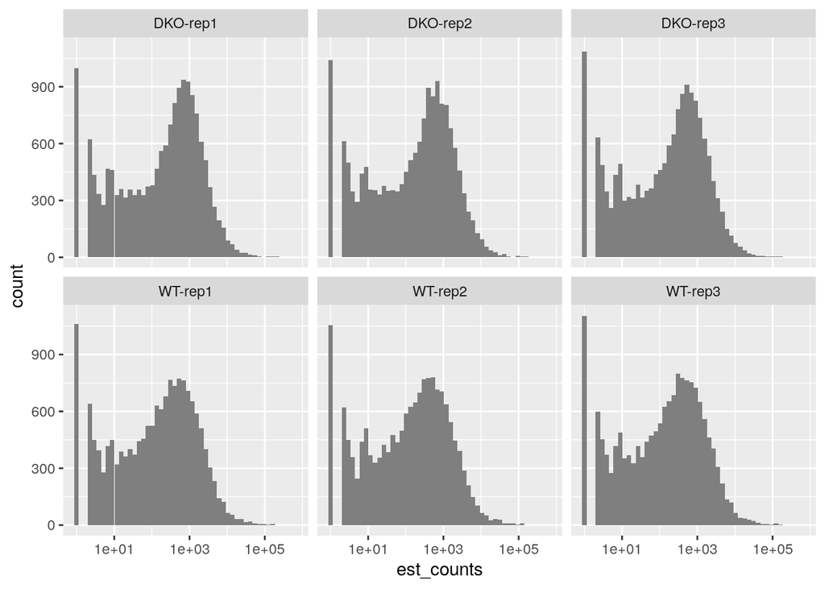

```r
tsv.df4 %>%
  ggplot(., aes(est_counts))+
  geom_histogram(fill = "grey50", bins = 50)+
  scale_x_log10()+
  facet_wrap(~sample, ncol = 3)
```

### Differential gene expression

Most RNAseq studies aim to find differentially expressed genes given some condition. DEseq2 is one program that is used for this. DEseq2 requires a few things to work, the first being a count matrix where the rows are genes and the columns are samples. This is the opposite of a tidy data frame but we can use tidyverse functions to make it.

The first thing we need to do is rejoin our gene identifier and names with `unite`, essentially the opposite of `separate`. Then we reshape the data with `spread`. We also need to make the column with identifiers into rownames and then the data frame into an actual matrix. Matrices only contain one type of data, integers in this case, so the rownames must not be included in the actual matrix.

```r
count.matrix <- tsv.df4 %>%                        # take the data frame
  unite(target_id, gene_id, gene, sep = "_") %>%   # join the column, the reverse of separate
  spread(sample, est_counts) %>%                   # reshape the data
  column_to_rownames("target_id") %>%              # turn the column target_id to rownames
  as.matrix()                                      # convert to matrix

head(count.matrix)
```

```
##                             DKO-rep1 DKO-rep2 DKO-rep3 WT-rep1 WT-rep2
## ENSMUSG00000000001.4_Gnai3      4896     4935     4015    4413    4924
## ENSMUSG00000000003.15_Pbsn         0        0        0       0       0
## ENSMUSG00000000028.15_Cdc45      276      218      173      91     131
## ENSMUSG00000000037.17_Scml2       15       10        6       9       8
## ENSMUSG00000000049.11_Apoh        13        1        3      16      12
## ENSMUSG00000000056.7_Narf       1300     1296     1057    1154    1157
##                             WT-rep3
## ENSMUSG00000000001.4_Gnai3     4792
## ENSMUSG00000000003.15_Pbsn        0
## ENSMUSG00000000028.15_Cdc45     119
## ENSMUSG00000000037.17_Scml2      11
## ENSMUSG00000000049.11_Apoh       10
## ENSMUSG00000000056.7_Narf      1126
```

The next thing DEseq2 needs is a data frame that tells it what the columns are. It can see the names, but it wants to know what treatment each column is so it knows which replicates belong to which. **Important:** this must be a factor with levels. If you want your reported fold changes to be change from WT to DKO, WT must be the first level.

```r
# make the data frame where the column is a factor with levels
conditions.df <- data.frame(condition = factor(c("DKO", "DKO", "DKO", "WT", "WT", "WT"), levels = c("WT", "DKO")))

# check those levels
levels(conditions.df$condition)
```

```
## [1] "WT"  "DKO"
```

```r
conditions.df
```

| condition |
| --- |
| DKO |
| DKO |
| DKO |
| WT |
| WT |
| WT |

Now we can actually run DEseq2. The first step is feed it the count matrix and conditions data frame. The design specifies how the counts in the matrix depend upon the variables in the conditions data frame, we use “condition” because that’s what our column in the data frame is named. This creates a DEseq object.

```r
ds1 <- DESeqDataSetFromMatrix(countData = count.matrix, # identify the count matrix
                              colData = conditions.df,  # identify the conditions data frame
                              design = ~ condition)     # specify the formula for DESeq to use
```

Then you run DEseq2 by simply calling this on the DEseq object.

```r
ds2 <- DESeq(ds1)
```

Then we perform what is referred to as “shrinkage”, to limit the effects of extreme fold changes due to genes with low counts and/or high variability.

```r
ds3 <- lfcShrink(ds2, coef = "condition_DKO_vs_WT", type = "apeglm")
```

### MA plots

In class, we looked at the effect if the shrinking process, which is easily illustrated if you look at these plots. The left plot is without the shrink, you can see that a lot of the points with low counts (left on the x axis) have large fold changes (large absolute value on the y axis), and that many of these points are relocated after shrinking. The shrinking effect diminishes as you move higher up the x axis (i.e. have higher counts).

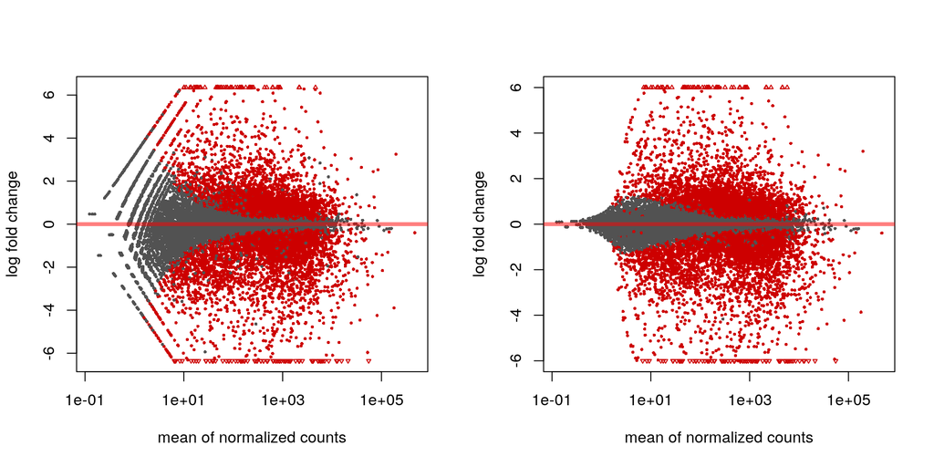

```r
par(mfrow=c(1,2))

plotMA(ds2)

plotMA(ds3)
```

### Continue with DESeq

Finally, we an retrieve our results in a data frame, converting the rownames back to a column.

```r
deseq.df <- as.data.frame(ds3) %>%
  rownames_to_column("target_id")

head(deseq.df)
```

|  | target_id | baseMean | log2FoldChange | lfcSE | pvalue | padj |
| --- | --- | --- | --- | --- | --- | --- |
| 1 | ENSMUSG00000000001.4_Gnai3 | 4718.911593 | -0.5224924 | 0.1233157 | 1.865784e-05 | 6.815963e-05 |
| 2 | ENSMUSG00000000003.15_Pbsn | 0.000000 | NA | NA | NA | NA |
| 3 | ENSMUSG00000000028.15_Cdc45 | 159.530345 | 0.4229109 | 0.2359678 | 6.359124e-02 | 1.147407e-01 |
| 4 | ENSMUSG00000000037.17_Scml2 | 9.712008 | -0.2516468 | 0.5490200 | 5.693375e-01 | 6.780831e-01 |
| 5 | ENSMUSG00000000049.11_Apoh | 9.673778 | -1.0975823 | 0.8715202 | 5.859022e-02 | 1.068849e-01 |
| 6 | ENSMUSG00000000056.7_Narf | 1186.360359 | -0.4063366 | 0.1108554 | 2.196416e-04 | 6.792353e-04 |

First, we’ll want to again separate our gene names and IDs using the same strategy as before. I knew in advance what I wanted to rename these columns to.

```r
deseq.df2 <- deseq.df %>%
  separate(target_id, into = letters[1:2], sep = "_") %>%
  dplyr::rename("ENSEMBL" = "a",
                "SYMBOL" = "b")

head(deseq.df2)
```

|  | ENSEMBL | SYMBOL | baseMean | log2FoldChange | lfcSE | pvalue | padj |
| --- | --- | --- | --- | --- | --- | --- | --- |
| 1 | ENSMUSG00000000001.4 | Gnai3 | 4718.911593 | -0.5224924 | 0.1233157 | 1.865784e-05 | 6.815963e-05 |
| 2 | ENSMUSG00000000003.15 | Pbsn | 0.000000 | NA | NA | NA | NA |
| 3 | ENSMUSG00000000028.15 | Cdc45 | 159.530345 | 0.4229109 | 0.2359678 | 6.359124e-02 | 1.147407e-01 |
| 4 | ENSMUSG00000000037.17 | Scml2 | 9.712008 | -0.2516468 | 0.5490200 | 5.693375e-01 | 6.780831e-01 |
| 5 | ENSMUSG00000000049.11 | Apoh | 9.673778 | -1.0975823 | 0.8715202 | 5.859022e-02 | 1.068849e-01 |
| 6 | ENSMUSG00000000056.7 | Narf | 1186.360359 | -0.4063366 | 0.1108554 | 2.196416e-04 | 6.792353e-04 |

Finally, we have a data frame we can work with. Most people want a volcano plot. But this one isn’t so nice looking.

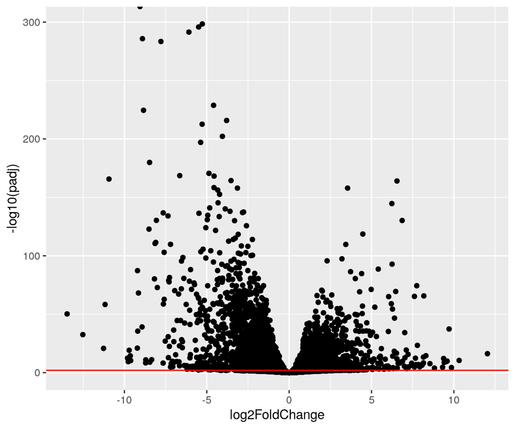

```r
deseq.df2 %>%
  ggplot(., aes(log2FoldChange, -log10(padj)))+
  geom_point()+
  geom_hline(aes(yintercept = -log10(.01)), color = "red")
```

One issue is that there are a ton of “significant” genes with q-values way above the line in the above plot. We can edit those so they are lower on the y axis by adding new columns to our data frame, essentially changing all values greater than some threshold, to that threshold. In this case, we choose 5. All genes with -log10(q-value) > 5 will become 5. We also want to mark these points so we can make them a different shape. We actually do this in reverse order, by assigning a category of too high or low to each, then changing the q-values accordingly.

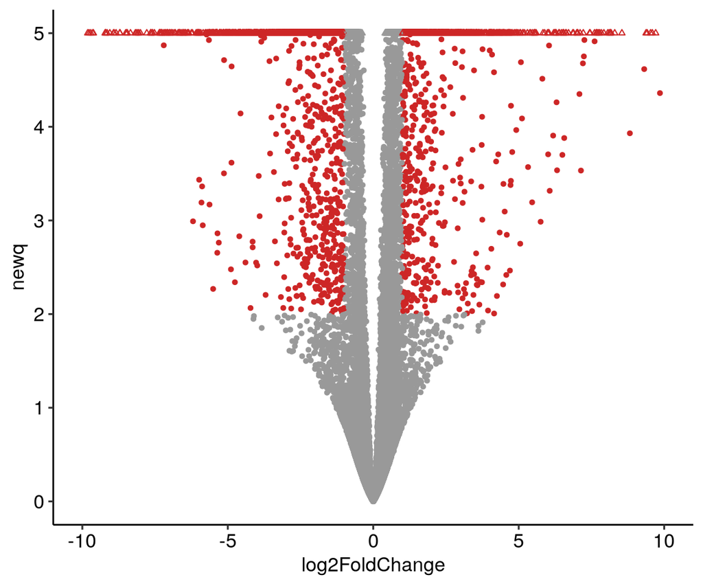

```r
plot.df <- deseq.df2 %>%
  mutate(logq = -log10(padj),                        # Make a new column that is the -log10() transform of the padj
         category = ifelse(logq > 5, "high", "low"), # Assign genes a category, if logq > 5, it's high, otherwise low
         newq = ifelse(category == "high", 5, logq)) # make new qval, if category is high, then 5, otherwise use the original one

# we color points a red only if they're statistically significant and have a fold change of greater than 2x or .5x
plot.df %>%
  ggplot(., aes(log2FoldChange, newq, shape = category, color = padj <= .01 & abs(log2FoldChange) >= 1))+
    geom_point(size = 1)+
    scale_shape_manual(values = c(2,19), guide = FALSE)+
    scale_color_manual(values = c("grey60", "firebrick3"), guide = FALSE)+
    scale_y_continuous(limits = c(0, 5))+
    scale_x_continuous(limits = c(-10, 10))+
    theme_pubr()
```

### GO analysis

GO (gene ontology) attempts to classify genes into functional categories. This helps make sense out of the around 6500 differentially expressed genes in this study. Unfortunately, we need to convert our gene names into some other form to do GO. Gene names across databases vary and change over time and it’s hard to keep track of it all. There’s no good solution for this.

First we need to convert our gene names, the `clusterProfiler` function `bitr` can do this for us. Clusterprofiler help page: https://yulab-smu.github.io/clusterProfiler-book/index.html

```r
names.df <- bitr(deseq.df2$SYMBOL,         # our input is our gene symbols
                 fromType = "SYMBOL",      # they are gene symbols, you need to read the help file to know what to put here
                 toType = c("ENTREZID"),   # we want them as entrezid's (NCBI), again, help files
                 OrgDb = org.Mm.eg.db) %>% # the organism database to use, mouse in this case
  group_by(SYMBOL) %>%                     # we group the resulting data frame by the symbol
  summarise(ENTREZID = ENTREZID[1])        # and only take the first entry we get from this

head(names.df)
```

| SYMBOL | ENTREZID |
| --- | --- |
| 0610009B22Rik | 66050 |
| 0610010F05Rik | 71675 |
| 0610010K14Rik | 104457 |
| 0610012G03Rik | 106264 |
| 0610030E20Rik | 68364 |
| 0610040J01Rik | 76261 |

We need to only take the first entry because there are gene with multiple entrezids and vice versa.

We then want to join these names to our deseq data frame. We also remove genes that don’t have an entrezid because we can’t do anything with those.

```r
named.deseq.df <- left_join(deseq.df2, names.df, by = "SYMBOL") %>%
  filter(!is.na(ENTREZID))

head(named.deseq.df)
```

|  | ENSEMBL | SYMBOL | baseMean | log2FoldChange | lfcSE | pvalue | padj | ENTREZID |
| --- | --- | --- | --- | --- | --- | --- | --- | --- |
| 1 | ENSMUSG00000000001.4 | Gnai3 | 4718.911593 | -0.5224924 | 0.1233157 | 1.865784e-05 | 6.815963e-05 | 14679 |
| 2 | ENSMUSG00000000003.15 | Pbsn | 0.000000 | NA | NA | NA | NA | 54192 |
| 3 | ENSMUSG00000000028.15 | Cdc45 | 159.530345 | 0.4229109 | 0.2359678 | 6.359124e-02 | 1.147407e-01 | 12544 |
| 4 | ENSMUSG00000000037.17 | Scml2 | 9.712008 | -0.2516468 | 0.5490200 | 5.693375e-01 | 6.780831e-01 | 107815 |
| 5 | ENSMUSG00000000049.11 | Apoh | 9.673778 | -1.0975823 | 0.8715202 | 5.859022e-02 | 1.068849e-01 | 11818 |
| 6 | ENSMUSG00000000056.7 | Narf | 1186.360359 | -0.4063366 | 0.1108554 | 2.196416e-04 | 6.792353e-04 | 67608 |

Then we want a list of upregulated genes, for example. We have some strict cutoffs on what upregulated means in this case.

```r
sig.up <- named.deseq.df %>%
  filter(padj <= .01 & log2FoldChange > 4) %>%
  pull(ENTREZID)
```

Then we can run a GO enrichment test. Didact is currently taking exception to running this, so it’s commented out.

```r
# go.up <- enrichGO(gene = sig.up,        # our query is the upregulated genes
#                   OrgDb = org.Mm.eg.db, # use the mouse database object
#                   ont = "BP")           # only search for GO "Biological Processes"
```

```r
# as.data.frame(go.up)
```